# BTC-USD

## BTC-USD today is +0200, 2025-11-20, 22:32:12

This crypto forecast was generated by gemini-2.0-flash API

## Daily Chart

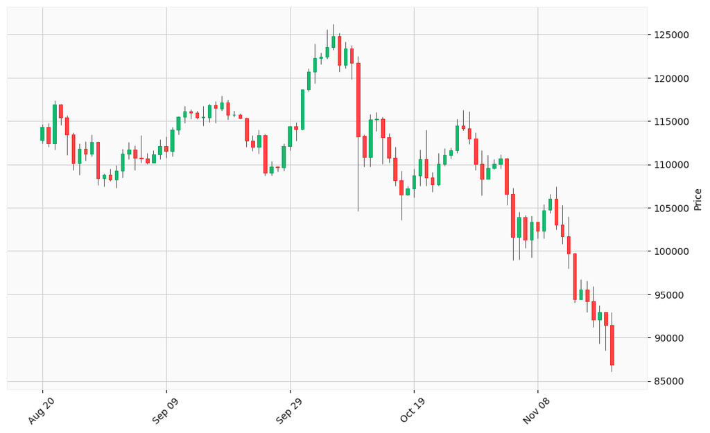

## Hourly Chart

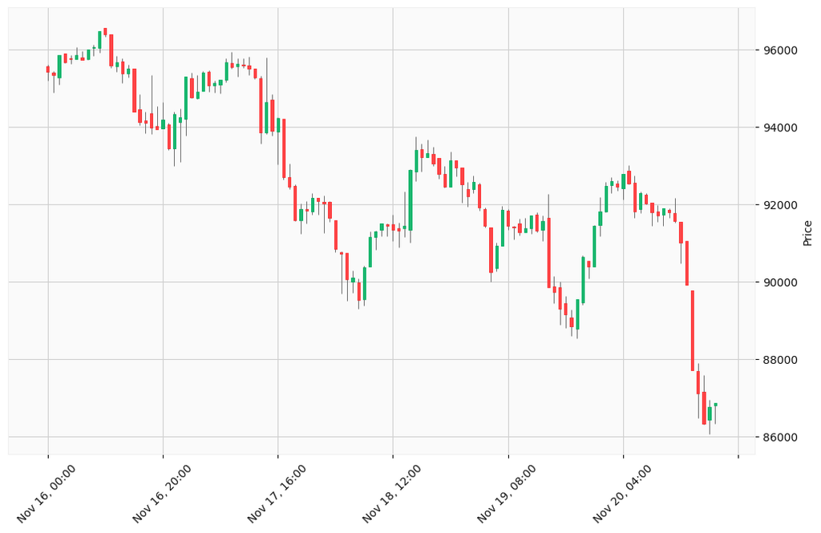

Okay, I will analyze the provided BTC-USD charts and generate buy and sell signals based on the specified steps.

Here’s an analysis of the BTC-USD market based on the provided data and search results.

**3. Trend Analysis:**

- **Short-Term Trend:** The short-term trend (based on the 5-day hourly chart) is bearish, with the price struggling to sustain upward momentum.
- **Long-Term Trend:** The long-term trend (based on the 3-month daily chart) was previously bullish but is now showing signs of a potential reversal. The break below the 108,000-110,000 support is a significant concern.

**4. News and Economic Analysis:**

- **Market Sentiment:** Recent news indicates a risk-off sentiment in the market.
- **Interest Rates:** Fading hopes of interest rate cuts by the Federal Reserve are contributing to the bearish sentiment.
- **Macroeconomic Indicators:**
  - Key macroeconomic indicators like CPI, GDP, and interest rates can significantly influence the crypto market.
  - Rising CPI can lead to tighter monetary policy, negatively impacting crypto.
  - Strong GDP growth can increase investor confidence and drive capital into crypto.
- **Long-term Holders Selling:** Long-term Bitcoin holders have been accelerating profit-taking.

**5. Scenario Evaluation:**

- **Bear Market Scenario:** Given the break of support levels and negative market sentiment, a bear market scenario is increasingly likely.
- **High Volatility:** Expect continued high volatility in the short term due to uncertainty in the market.

**6. Signal Generation:**

Based on the analysis, here are potential trading signals:

- **Signal 1:** `Signal Type: Sell Cryptocurrency: Bitcoin (BTC-USD) Confidence Level: Medium Take Profit probability: 80% Justification: Price has broken below key support levels (108,000-110,000) on the daily chart, indicating a potential trend reversal. Negative market sentiment and fading hopes of interest rate cuts add to the bearish outlook. Relevant Data: Daily chart showing a break below support, negative news sentiment. Recommended Action: Consider selling a portion of holdings or opening a short position, set stop-loss above 115,000.`
- **Signal 2:** `Signal Type: Sell Cryptocurrency: Bitcoin (BTC-USD) Confidence Level: Medium Take profit probability: 70% Justification: The short-term hourly chart shows continued struggle to maintain levels above 92,000. Relevant Data: Hourly chart data Recommended Action: Short sell with target around 85000.`
- **Signal 3:** `Signal Type: Hold Cryptocurrency: Bitcoin (BTC-USD) Confidence Level: Low Take Profit probability: 30% Justification: The market may be oversold in the short term, which may present a short term opportunity to buy. Relevant Data: Crypto Fear & Greed index may indicate extreme fear, presenting opportunity to buy. Recommended Action: Hold current position, and wait for a better opportunity.`

**Disclaimer:** These signals are based on the provided data and analysis and should not be considered financial advice. Cryptocurrency trading involves substantial risk, and you should conduct your own research and consult with a financial advisor before making any investment decisions.